# Part II - (Presentation on the Ford GoBike System Dataset)

## by (Saad BinOnayq)

## Investigation Overview

> In this exploration, I am trying to identify the most important variables related to the Ford Bike Sharing system, and this data covers the Greater San Francisco Bay Area in February 2019, and I will cover in it: the distribution of trips over hours, the distribution of trip distance among all trips, how the duration of riding a bike differs on different week days.

## Dataset Overview

> This data contains approximately 175,000 rows, each row representing a bike ride, in San Francisco Bay in February 2019. This data contains 15 original features:
> - The start and end time of the trip.
> - The name, number and location of the start and end of the trip.
> - The customer's membership type, year of birth and gender
> - Is share the bike on all trips.

## The distribution of trips over hours

**In the plot below, we can find that the night hours (22 pm to 5 am) do not have many trips, because it is a time for sleep and rest, but the two periods in which trips are most concentrated are the period (6 am to 9 am) and (4 pm to 6 pm) because they are working hours and jobs.**

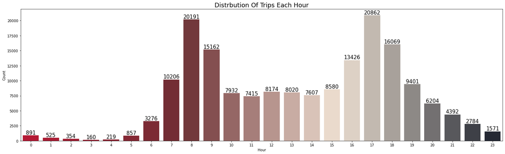

## The distribution of trip distance among all trips

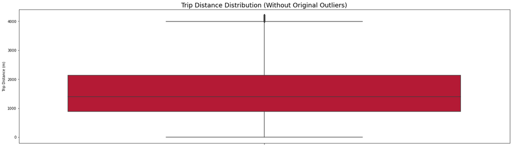

## How the duration of riding a bike differs on different week days.

**In the plot below, it appears that bike rides tend to be longer on weekends than on weekday،this gives the impression that the weekend could be for sports trips or outings that are not usual on weekday.**

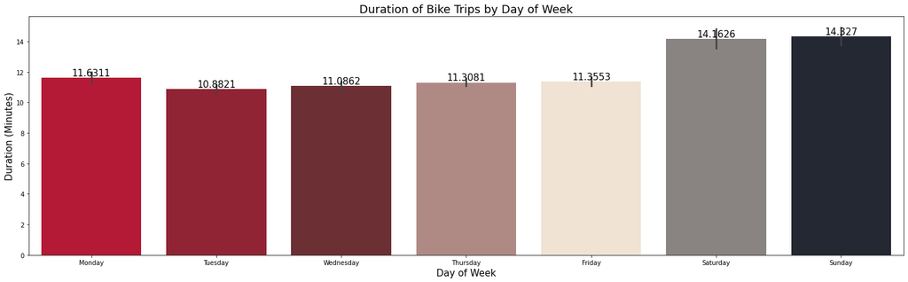